# edgar

Jung

```r
rm(list=ls())
library(knitr)
library(dplyr)
library(stringr)
library(rbenchmark)
# Download Forms 10-K/10 Q from SEC
library(edgar)
# For sentiment datasets
library(data.table)
library(RSQLite)
library(parallel)
library(doSNOW)
library(sentimentr)
library(quanteda)
library(tidytext)
library(textstem)
library(rvest)
library(ggplot2)
library(tidyr)
library(reshape2)
library(OpenImageR)

# part B
library(tidyquant)
library(tm)
library(SentimentAnalysis)

# part C
library(koRpus)
library(stm)
```

```r
# make progress bar
optionSnow <- function (iterations) {
  i <- iterations
  pb <- txtProgressBar(max = i, style = 3)
  progress <- function(n) setTxtProgressBar(pb, n)
  opts <- list(progress = progress)
  return(opts)
}

# fetch data from back up database
loaddf <- function (dbname, dfname) {
  con <- dbConnect(RSQLite::SQLite(), paste0(dbname,".sqlite"))
  df <- dbGetQuery(con, paste("SELECT * FROM", dfname))
  return(df)
  dbDisconnect(con)
}

# save data to back up database
backup <- function (dbname, dfname, df) {
  con <- dbConnect(SQLite(), paste0(dbname, ".sqlite"))
  dbWriteTable(con, dfname, df, overwrite=TRUE)
  print(paste("Dataframe", dfname, "has been written to back up database!"))
  print(dbListTables(con))
  dbDisconnect(con)
}

# check the database tables
dbcheck <- function (dbname) {
  con <- dbConnect(SQLite(), paste0(dbname, ".sqlite"))
  print((dbListTables(con)))
  dbDisconnect(con)
}

# two functions to reorder the word frequency
# for each group
# in ggplot
reorder_within <- function(x, by, within, fun = mean, sep = "___", ...) {
  new_x <- paste(x, within, sep = sep)
  stats::reorder(new_x, by, FUN = fun)
}

scale_x_reordered <- function(..., sep = "___") {
  reg <- paste0(sep, ".+$")
  ggplot2::scale_x_discrete(labels = function(x) gsub(reg, "", x), ...)
}
```

# Part A

## Download text filings

All filings of S&P 500 companies and converted HTML files can be obtained using `getFilingsHTML` function and `parallel processing`. Although `parallel processing` is normally not recommended for downloading due to network overlaod, downloading edgar filings sequentially took even more time to finish up tasks in some benchmark tests. The overall result shows that `sequential processing` could deal with about 20 companies in 1 hour while `parallel processing` could deal with about 65 to 70 companies in 1 hour showing much faster speed. I think this is possible as downloading edgar filings does not requre an intensive network per download. However, I found that computer can stop downloading process at some point if the network become not stable with extreme `parallel processing`. Therefore, I decided to use `parallel processing` with a limited number of 4 workers which is reasonable number to avoid network bottle neck and ensure a stable download speed. Before downloading the text files, `master index` should be made in advance without `Parallel processing` as it may be able to corrupt each process so that some index rda files become incomplete.

```r
# due to large data size
# all data will be downloaded in external hard drive
# with the path "D:/edgar"
setwd("D:/edgar")
edgar::getMasterIndex(2009:2019)
```

```r
# read S&P 500 company list table
# which is copied from appendix
companies <- readxl::read_xlsx("C:/r_working_directory/gitgit/edgar/companies.xlsx")
# assumed that companies with same cik
# are treated as one single unit
# as edgar filings are made per CIK
companies <- companies[!duplicated(companies$CIK),]

companies$CIK <- as.character(companies$CIK)

# extract all cik and length of it
cik <- companies$CIK

iter <- length(cik)
iter_year <- 11  # 2009 to 2019
iter_total <- iter*iter_year # total number of iterations

opts_total <- optionSnow(iter_total)
opts_year <- optionSnow(iter_year)
```

```r
# downloading textfiles

cl <- makePSOCKcluster(detectCores()-4)
registerDoSNOW(cl)
clusterEvalQ(cl,
             library(edgar))

foreach (i = 1:iter, .combine = rbind) %:%
  foreach (k = 2009:2019, .combine = c, .options.snow = opts_total) %dopar% {
    this_cik <- cik[i]
    setwd("D:/edgar")
    getFilingsHTML(cik.no = this_cik,
               form.type = c("10-K","10-Q"),
               filing.year = k)
    gc()
    return(NULL)
  }
doParallel::stopImplicitCluster()
stopCluster(cl)
rm(cl, opts_total)

# there are missing filings for some companies
# total 497 companies for 10-K
# total 499 companies for 10-Q

# check which companies (CIK) have no filings
cik_list_q <- list.files("D:/edgar/Edgar filings_HTML view/Form 10-Q")
companies$CIK[!companies$CIK %in% cik_list_q]
# There is no 10-Q filings for the following CIK:
# 1132979
cik_list_k <- list.files("D:/edgar/Edgar filings_HTML view/Form 10-K")
companies$CIK[!companies$CIK %in% cik_list_k]
# There is no 10-K filings for the following CIK:
# 1755672 1751788 1132979

# comeback to original working directory
# setwd("C:/r_working_directory/gitgit/edgar")

companies_q <- companies %>% filter(! CIK %in% "1132979")
companies_k <- companies %>% filter(! CIK %in% c("1755672", "1751788", "1132979"))
```

## Text Processing

The downloaded text files should be processed in a tidy format to be used for further analyses. In this section, using html filings of `10-Q` and `10-K` forms, I will make a database in the local environment *(“C:/r_working_directory/gitgit/edgar”)*. The database stores all relevent data of each document. In order to make new dataset, I retrieved each filing detail from `getFilingInfo` function and added some other necessary data like GICS. Then, I added pre processed texts to corresponding documents.

```r
# 10-Q

# prepare
setwd("D:/edgar")
cik_list_q <- list.files("D:/edgar/Edgar filings_HTML view/Form 10-Q")

# make db in my local environment
# so that I do not need to use external hard drive
# db file size will be affordable

setwd("C:/r_working_directory/gitgit/edgar")
con <- dbConnect(SQLite(),"edgar.sqlite")

for (k in 1:length(cik_list_q)) {

  # pick CIK
  this_cik <- cik_list_q[k]

  # get filing information of this CIK
  print(paste0("Getting filing information for ", k, "th CIK: ", this_cik))
  setwd("D:/edgar")
  this_filing_info <- getFilingInfo(this_cik, 2009:2019, form.type = "10-Q")

  # access all 10-Q file of this CIK
  filings <- list.files(paste0("D:/edgar/Edgar filings_HTML view/Form 10-Q/",
                               this_cik,"/"),
                        full.names = T)
  opts <- optionSnow(length(filings))

  # make clusters for parallel processing
  cl <- makePSOCKcluster(detectCores()-1)
  registerDoSNOW(cl)
  clusterEvalQ(cl, {
    library(dplyr)
    library(edgar)
    library(xml2)
    library(rvest)
    get_text <- function(filing) {
      read_html(filing, options="HUGE") %>%
        html_text() %>%
        gsub("[\r\n]", " ", .) %>%
        trimws()
    }
  }
  )

  print(paste0("Start parallel processing for ", k, "th CIK: ", this_cik))
  start <- Sys.time()

  # not all filings are 11!! fix this
  Q <- foreach(i = 1:length(filings), .options.snow = opts, .combine = rbind) %dopar% {

    setwd("D:/edgar")

    this_filings <- filings[i]

    # extract all texts from html form
    # and trim
    # with custom function get_text

    this_text <- get_text(this_filings)

    # combine necessary data fields
    this_q <-  this_filing_info[i,] %>%
      mutate(symbol = companies %>%
               filter(CIK == this_cik) %>%
               select(Symbol) %>%
               pull()
             ,
             GICS = companies %>%
               filter(CIK == this_cik) %>%
               select(`GICS Sector`) %>%
               pull(),
             GICS_sub = companies %>%
               filter(CIK == this_cik) %>%
               select(`GICS Sub Industry`) %>%
               pull(),
             text = this_text
      )

    this_q$text <- gsub('[[:digit:]]+',' ', this_q$text)
    this_q$text <- gsub('[[:punct:]]+',' ', this_q$text)

    return(this_q)
  }
  doParallel::stopImplicitCluster()
  stopCluster(cl)
  rm(cl)
  gc()

  print(paste0("Finished parallel processing! It took ", Sys.time()-start, "to process"))

  # backup
  setwd("C:/r_working_directory/gitgit/edgar")
  dbWriteTable(con, "10_Q", Q, append=TRUE)
  print(paste("Dataframe has been written to back up database!"))
}

# disconnect db
dbDisconnect(con)
```

```r
# 10-K

# prepare
setwd("D:/edgar")
cik_list_k <- list.files("D:/edgar/Edgar filings_HTML view/Form 10-K")

setwd("C:/r_working_directory/gitgit/edgar")
con <- dbConnect(SQLite(), "edgar.sqlite")

for (k in 1:length(cik_list_k)) {

  # pick CIK
  this_cik <- cik_list_k[k]
  # get filing information of this CIK

  print(paste0("Getting filing information for ", k, "th CIK: ", this_cik))
  setwd("D:/edgar")
  this_filing_info <- getFilingInfo(this_cik, 2009:2019, form.type = "10-K")

  # access all 10-Q file of this CIK
  filings <- list.files(paste0("D:/edgar/Edgar filings_HTML view/Form 10-K/",
                               this_cik,"/"),
                        full.names = T)
  opts <- optionSnow(length(filings))

  # make clusters for parallel processing
  cl <- makePSOCKcluster(detectCores()-1)
  registerDoSNOW(cl)
  clusterEvalQ(cl, {
    library(dplyr)
    library(edgar)
    library(xml2)
    library(rvest)
    get_text <- function(filing) {
      read_html(filing, options="HUGE") %>%
        html_text() %>%
        gsub("[\r\n]", " ", .) %>%
        trimws()
    }
  }
  )

  print(paste0("Start parallel processing for ", k, "th CIK: ", this_cik))
  start <- Sys.time()

  K <- foreach(i = 1:length(filings), .options.snow = opts, .combine = rbind) %dopar% {

    setwd("D:/edgar")

    # cut 10-Q files for each year from 2009 to 2019
    # three filings per year

    this_filings <- filings[i]

    # extract all texts from html form
    # and trim
    # with custom function get_text

    this_text <- get_text(this_filings)

    # combine necessary data fields
    this_k <-  this_filing_info[i,] %>%
      mutate(symbol = companies %>%
               filter(CIK == this_cik) %>%
               select(Symbol) %>%
               pull()
             ,
             GICS = companies %>%
               filter(CIK == this_cik) %>%
               select(`GICS Sector`) %>%
               pull(),
             GICS_sub = companies %>%
               filter(CIK == this_cik) %>%
               select(`GICS Sub Industry`) %>%
               pull(),
             text = this_text
      )

    this_k$text <- gsub('[[:digit:]]+',' ', this_k$text)
    this_k$text <- gsub('[[:punct:]]+',' ', this_k$text)

    return(this_k)
  }
  doParallel::stopImplicitCluster()
  stopCluster(cl)
  rm(cl)
  gc()

  print(paste0("Finished parallel processing! It took ", Sys.time()-start, "to process"))

  # backup
  setwd("C:/r_working_directory/gitgit/edgar")
  dbWriteTable(con, "10_K", K, append=TRUE)
  print(paste("Dataframe has been written to back up database!"))
}

# disconnect db
dbDisconnect(con)
```

```r
con <- dbConnect(SQLite(), "edgar.sqlite")

dbListTables(con)

# create index for fast query
dbSendQuery(con, "CREATE INDEX cik_idx_Q ON '10_Q' (cik)")
dbSendQuery(con, "CREATE INDEX cik_idx_K ON '10_K' (cik)")

dbDisconnect(con)
```

After creating my own dataset, I tokenised and lemmatised the processed text data for further analyses. I implemented lemmatisation for more accurate insights into the bag of words approach.

```r
# company name to stop words
# other words such as United States or Q will be removed with tf-idf method
# as they appear in all documents

data("stop_words")

companyname <- unlist(strsplit(companies$Security, split = " ")) %>%
  tolower() %>%
  unique()

# all digits and pucntuation in the texts are removed
# in the previous process
# so company name stop words should be also
# processed in the same way
# to find out and remove corressponding words correctly

companyname <- gsub('[[:digit:]]+',' ', companyname)
companyname <- gsub('[[:punct:]]+',' ', companyname)

# divide by space for complete company name stop words
companyname <- unlist(strsplit(companyname, split = " ")) %>%
  unique() %>%
  stringi::stri_remove_empty()

stop_words <- rbind(stop_words,tibble(word=companyname,lexicon="custom"))
```

```r
con <- dbConnect(SQLite(), "edgar.sqlite")
cik_list_q <- list.files("D:/edgar/Edgar filings_HTML view/Form 10-Q")

for (k in 1:length(cik_list_q)) {

  this_cik <- cik_list_q[k]

  this_q <- dbGetQuery(con, paste0("SELECT * FROM '10_Q' WHERE cik == ", this_cik))
  print(paste0("Fetched ", k, "th CIK: ", this_cik, "from database"))
  this_q$date.filed <- zoo::as.Date(this_q$date.filed)

  opts <- optionSnow(nrow(this_q))

  # make clusters for parallel processing
  cl <- makePSOCKcluster(detectCores()-1)
  registerDoSNOW(cl)
  clusterEvalQ(cl, {
    library(dplyr)
    library(tidytext)
    library(textstem)
  }
  )

  print(paste0("Start parallel processing for ", k, "th CIK: ", this_cik))
  start <- Sys.time()

  Q <- foreach(i=1:nrow(this_q),
               .options.snow = opts,
               .combine = rbind) %dopar% {

    document <- this_q[i,]

    # making word tokens upon text
    tokens_h <- document %>%
      unnest_tokens(word,text) %>%
      # count number of words
      count(word,cik) %>%
      # remove stop words
      anti_join(stop_words)

    tokens_h$token_length <- nchar(tokens_h$word)

    tokens_h <- tokens_h %>%
      filter(token_length > 2, token_length <= 15)

    # lemmatisation unify form of tokens into their root form
    # so that words which have actually same meaning
    # can be considered as same word

    # make_lemma_dirctionary function gives more targeted and smaller dictionary
    # for a particular document (i.e. document specific lemma dictionary)
    # which can speed up the lemmatisation process

    lemma_dictionary_tt <- make_lemma_dictionary(tokens_h$word, engine = 'treetagger')
    tokens_h$word <- lemmatize_words(tokens_h$word, lemma_dictionary_tt)

    tokens_h <- tokens_h %>%
      group_by(word, cik) %>%
      summarise(n = sum(n)) %>%
      ungroup() %>%
      left_join(document[, !colnames(document) == "text"])

    return(tokens_h)
  }
  doParallel::stopImplicitCluster()
  stopCluster(cl)
  rm(cl)
  gc()

  print(paste0("Finished parallel processing! It took ",
               Sys.time()-start, "to process"))

  # backup
  dbWriteTable(con, "10_Q_token", Q, append=TRUE)
  print(paste("Dataframe has been written to back up database!"))
  rm(this_cik, this_q, opts, Q)
  gc()
}

dbSendQuery(con, "CREATE INDEX cik_idx_Q_token ON '10_Q_token' (cik)")

# disconnect db
dbDisconnect(con)
```

```r
con <- dbConnect(SQLite(), "edgar.sqlite")
cik_list_k <- list.files("D:/edgar/Edgar filings_HTML view/Form 10-K")

for (k in 1:length(cik_list_k)) {

  this_cik <- cik_list_k[k]

  this_k <- dbGetQuery(con, paste0("SELECT * FROM '10_K' WHERE cik == ", this_cik))
  print(paste0("Fetched ", k, "th CIK: ", this_cik, " from database"))
  this_k$date.filed <- zoo::as.Date(this_k$date.filed)

  opts <- optionSnow(nrow(this_k))

  # make clusters for parallel processing
  cl <- makePSOCKcluster(detectCores()-1)
  registerDoSNOW(cl)
  clusterEvalQ(cl, {
    library(dplyr)
    library(tidytext)
    library(textstem)
  }
  )

  print(paste0("Start parallel processing for ", k, "th CIK: ", this_cik))
  start <- Sys.time()

  K <- foreach(i=1:nrow(this_k),
               .options.snow = opts,
               .combine = rbind) %dopar% {

    document <- this_k[i,]

    # making word tokens upon text
    tokens_h <- document %>%
      unnest_tokens(word,text) %>%
      # count number of words
      count(word,cik) %>%
      # remove stop words
      anti_join(stop_words)

    tokens_h$token_length <- nchar(tokens_h$word)

    tokens_h <- tokens_h %>%
      filter(token_length > 2, token_length <= 15)

    # lemmatisation unify form of tokens into their root form
    # so that words which have actually same meaning
    # can be considered as same word

    # make_lemma_dirctionary function gives more targeted and smaller dictionary
    # for a document
    # which can speed up the lemmatisation process

    lemma_dictionary_tt <- make_lemma_dictionary(tokens_h$word, engine = 'treetagger')
    tokens_h$word <- lemmatize_words(tokens_h$word, lemma_dictionary_tt)

    tokens_h <- tokens_h %>%
      group_by(word, cik) %>%
      summarise(n = sum(n)) %>%
      ungroup() %>%
      left_join(document[, !colnames(document) == "text"])

    return(tokens_h)
  }
  doParallel::stopImplicitCluster()
  stopCluster(cl)
  rm(cl)
  gc()

  print(paste0("Finished parallel processing! It took ",
               Sys.time()-start, "to process"))

  # backup
  dbWriteTable(con, "10_K_token", K, append=TRUE)
  print(paste("Dataframe has been written to back up database!"))
  rm(this_cik, this_k, opts, K)
  gc()
}

dbSendQuery(con, "CREATE INDEX cik_idx_K_token ON '10_K_token' (cik)")

# disconnect db
dbDisconnect(con)
```

## TF-IDF

Using lemmatised words, I will provide outlines of TF-IDF weights for important keywords across various levels. Firstly, TF-IDF should be calculated across each category corpus. TF-IDF can remove useless words which appear too common or too rare in the corpus by cutting off based on its values. Then, word frequency can be summed up to figure out the top 10 key words in the corpus.

After some trials with tf_idf weighting, I realised that tf_idf cannot trim all the words perfectly that I do not want. I added some unnecessary words as possible stop words which should be removed for clearer key words analysis in a corpus.

```r
stop_words <- rbind(stop_words,
                    tibble(word=c("january", "february", "march",
                                  "april", "may", "june",
                                  "july", "august","september",
                                  "october","november","december",
                                  "billion", "million", "dollar",
                                  "percent"),lexicon="custom"))

stop_words <- rbind(stop_words,
                    tibble(word=c("content" ,"defer", "deferred",
                                  "net", "reporting", "lower",
                                  "ebitda", "gaap", "thousand",
                                  "reporting"),lexicon="custom"))
```

I made unique doument id (format: cik_date.filed) by combining `cik` and `date.filed` columns to cacluate `tf_idf` for the corpus. However, I found that *some combinations of word and doc_id are duplicated*. This caused a problem with some negative tf_idf values. After in-depth investigation on the dataset in the database, I realised that this was due to *duplicated master index data*. Following is an example of error in master index:

e.g. cik: 779152

[output not shown]

As shown in the example, `row 1` and `row 2` are duplicated. It is difficult to know the exact reason why the same filing is listed twice as a duplicate in EDGAR. Therefore, I assummed that these kinds of duplicate documents are *identical* if their `date.filed` are same and summarised `frequency values (n)` of the duplicated tokenised words as their *average*. I used parallel proessing in order to avoid extreme pressure on the memory.

After dealing with this problem, I will implement TF-IDF weighting on:

1 - Entire corpus 2 - Industry level corpus 3 - market level corpus

Then, I will trim too rare and too common tokens (words) using the tf-idf values. Finally, I will provide top 10 words (important keywords) for the three levels.

### TF-IDF (10-Q)

```r
# dealing with duplicated documents
# this chunk code inspect thorugh whole data
# by each CIK
# and deal with the identical documents

companies_q <- companies %>% filter(! CIK %in% "1132979")
companies_k <- companies %>% filter(! CIK %in% c("1755672", "1751788", "1132979"))

# make clusters for parallel processing
cl <- makePSOCKcluster(detectCores()-1)
registerDoSNOW(cl)
clusterEvalQ(cl, {
  library(dplyr)
  library(tidyr)
  library(tidytext)
  library(RSQLite)
  library(zoo)
}
)

opts <- optionSnow(nrow(companies_q))

Q_token <- foreach(i=1:nrow(companies_q),
                   .options.snow = opts,
                   .combine = rbind) %dopar% {

  con <- dbConnect(SQLite(), paste0("edgar.sqlite"))
  this_cik <- companies_q$CIK[i]

  this_q <- dbGetQuery(con, paste0("SELECT * FROM `10_Q_token` WHERE cik == ",
                                   this_cik))

  this_q$date.filed <- zoo::as.Date(this_q$date.filed)
  this_q <- this_q %>%
    unite(., "doc_id", cik, date.filed, remove = FALSE) %>%
    as_tibble()

  this_q <- this_q %>%
    group_by(word, doc_id, cik, company.name, form.type,
             date.filed, quarter, filing.year, symbol, GICS, GICS_sub) %>%
    summarise(n = round(mean(n))) %>%
    ungroup()

  # remove repititive words
  # at least for three times
  # e.g. "aaa"

  customstopwords <- this_q$word[grepl("\\b(\\S+?)\\1\\1\\S*\\b", this_q$word)]

  this_q <- this_q %>%
    filter(!word %in% customstopwords)

  dbDisconnect(con)

  return(this_q)
}

doParallel::stopImplicitCluster()
stopCluster(cl)
rm(cl)
gc()

# overwrite
backup("edgar", "10_Q_token", Q_token)
```

```r
# tf-idf on entire corpus
tokens_tf_idf_q <- Q_token %>%
  bind_tf_idf(word,doc_id,n)

hist(tokens_tf_idf_q$tf_idf,breaks = 200,main="TF-IDF plot")

## trimming
# remove too rare terms
tokens_tf_idf_q <- tokens_tf_idf_q %>%
  filter(tf_idf<0.002)

hist(tokens_tf_idf_q$tf_idf,breaks = 200,main="TF-IDF plot")

# remove too common terms across the documents
tokens_tf_idf_q <- tokens_tf_idf_q %>%
  filter(tf_idf>0.0003)

hist(tokens_tf_idf_q$tf_idf,breaks = 200,main="TF-IDF plot")

# back up
backup("edgar", "tokens_tf_idf_Q", tokens_tf_idf_q)

con <- dbConnect(SQLite(), paste0("edgar.sqlite"))
dbSendQuery(con, "CREATE INDEX cik_idx_tf_idf_Q ON 'tokens_tf_idf_Q' (cik)")
dbDisconnect(con)
```

[output not shown]

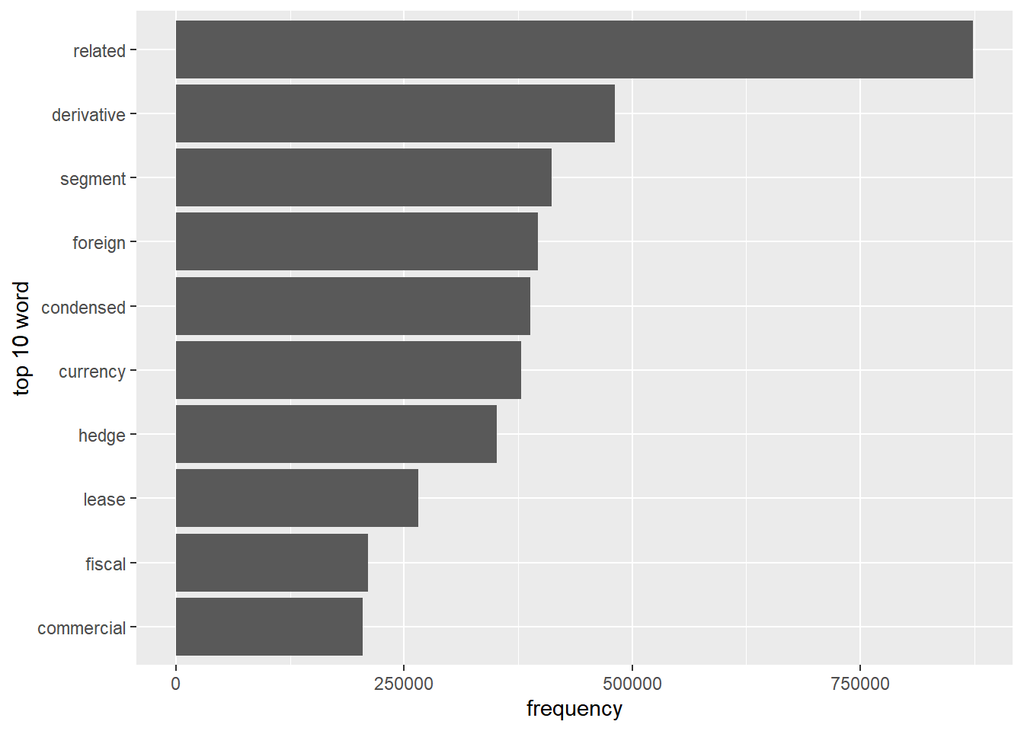

```r
# entire corpus
top_10_q <- tokens_tf_idf_q %>%
  group_by(word) %>%
  anti_join(stop_words) %>%
  summarise(n = sum(n)) %>%
  top_n(10, n) %>%
  select(-n) %>%
  mutate(rank = row_number())

ggplot(top_10_q,
       aes(x = reorder(word, n), y = n)) +
  geom_bar(stat = "identity") +
  coord_flip() +
  ylab("frequency") +
  xlab("top 10 word")
```

```r
# tf-idf on industry level

l <- list()
for (i in 1:length(unique(Q_token$GICS))) {

  this_industry <- unique(Q_token$GICS)[i]

  print(this_industry)

  # corpus by each industry
  # and then calculate tf-idf
  tokens_tf_idf_q <- Q_token %>%
    filter(GICS == this_industry) %>%
    bind_tf_idf(word,doc_id,n)

  l[[i]] <- tokens_tf_idf_q

  rm(this_industry)
  gc()
}

tokens_tf_idf_q <- rbindlist(l)
rm(l)
gc()

hist(tokens_tf_idf_q$tf_idf,breaks = 200,main="TF-IDF plot")

## trimming
# remove too rare terms
tokens_tf_idf_q<- tokens_tf_idf_q %>%
  filter(tf_idf<0.002)

hist(tokens_tf_idf_q$tf_idf,breaks = 200,main="TF-IDF plot")

# remove too common terms across the documents
tokens_tf_idf_q <- tokens_tf_idf_q %>%
  filter(tf_idf>0.0003)

hist(tokens_tf_idf_q$tf_idf,breaks = 200,main="TF-IDF plot")
```

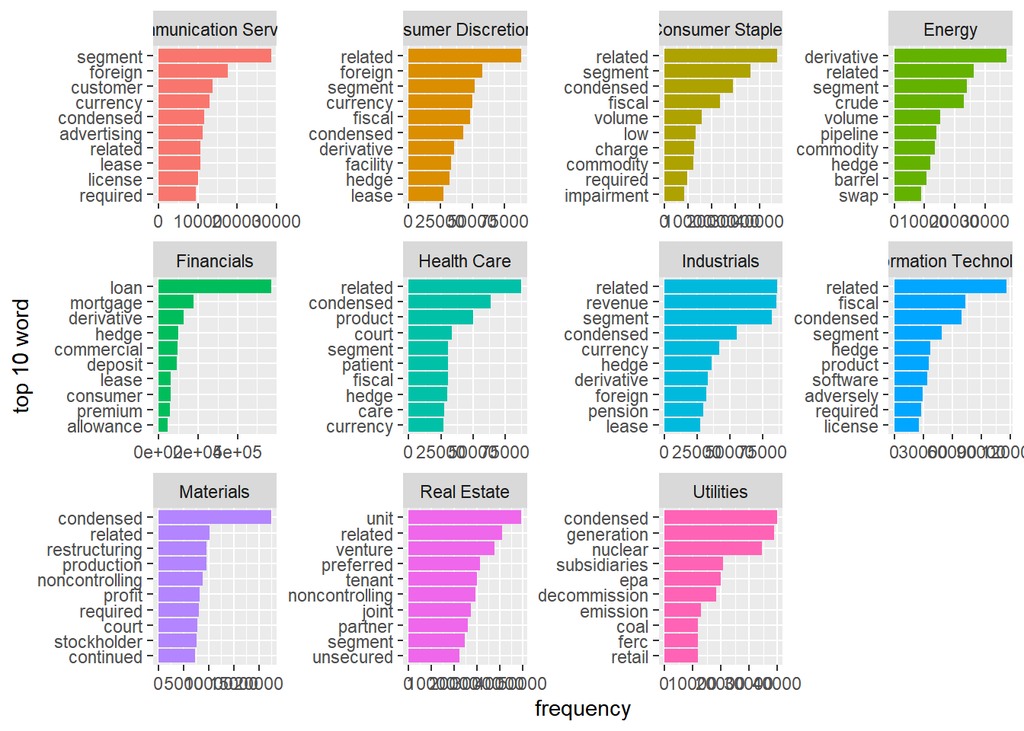

```r
# top 10 words
# for 11 GICS industries
top_10_q_industry <- tokens_tf_idf_q %>%
  group_by(word, factor(GICS)) %>%
  anti_join(stop_words) %>%
  summarise(n = sum(n)) %>%
  ungroup() %>%
  group_by(`factor(GICS)`) %>%
  top_n(10, n) %>%
  arrange(`factor(GICS)`, desc(n)) %>%
  mutate(rank = row_number()) %>%
  rename(GICS = `factor(GICS)`)

ggplot(top_10_q_industry,
       aes(x = reorder_within(word, n, GICS),
           y = n, group = factor(GICS),
           fill = factor(GICS))) +
  geom_bar(stat = "identity") +
  scale_x_reordered() +
  facet_wrap(~ GICS, scales = "free") +
  ylab("frequency") +
  xlab("top 10 word") +
  theme(legend.position = "none") +
  coord_flip()
```

```r
# tf-idf on market level
l <- list()
for (i in 1:length(unique(Q_token$GICS_sub))) {

  this_market <- unique(Q_token$GICS_sub)[i]

  print(paste("tf-idf on"), this_market)
  # corpus by each market
  # and then calculate tf-idf
  tokens_tf_idf_q <- Q_token %>%
    filter(GICS_sub == this_market) %>%
    bind_tf_idf(word,doc_id,n)

  l[[i]] <- tokens_tf_idf_q
}

tokens_tf_idf_q <- rbindlist(l)

hist(tokens_tf_idf_q$tf_idf,breaks = 200,main="TF-IDF plot")

## trimming
# remove too rare terms
tokens_tf_idf_q <- tokens_tf_idf_q %>%
  filter(tf_idf<0.002)

hist(tokens_tf_idf_q$tf_idf,breaks = 200,main="TF-IDF plot")

# remove too common terms across the documents
tokens_tf_idf_q <- tokens_tf_idf_q %>%
  filter(tf_idf>0.0003)

hist(tokens_tf_idf_q$tf_idf,breaks = 200,main="TF-IDF plot")
```

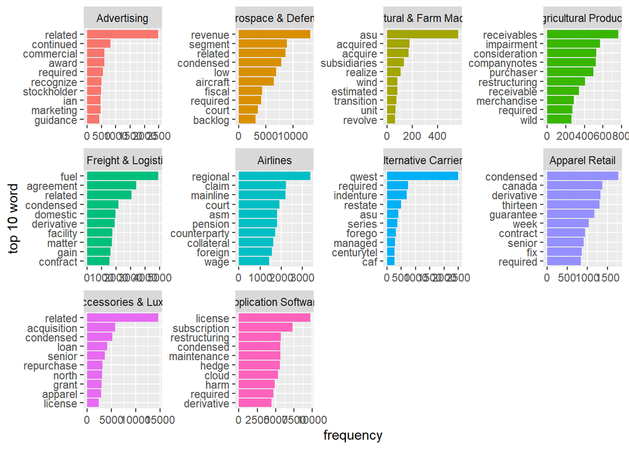

```r
# 128 markets (GICS sub)
top_10_q_market <- tokens_tf_idf_q %>%
  group_by(word, factor(GICS_sub)) %>%
  anti_join(stop_words) %>%
  summarise(n = sum(n)) %>%
  ungroup() %>%
  group_by(`factor(GICS_sub)`) %>%
  top_n(10, n) %>%
  arrange(`factor(GICS_sub)`, desc(n)) %>%
  mutate(rank = row_number()) %>%
  rename(GICS_sub = `factor(GICS_sub)`)

# there are total 128 markets
# which is too large number to display
# I will extract 10 markets to show as an example

top_10_q_market_sample <- top_10_q_market %>%
  head(., 100)

ggplot(top_10_q_market_sample,
       aes(x = reorder_within(word, n, GICS_sub),
           y = n, group = factor(GICS_sub),
           fill = factor(GICS_sub))) +
  geom_bar(stat = "identity") +
  scale_x_reordered() +
  facet_wrap(~ GICS_sub, scales = "free") +
  ylab("frequency") +
  xlab("top 10 word") +
  theme(legend.position = "none") +
  coord_flip()

# save all
save(top_10_q, top_10_q_industry, top_10_q_market, file = "top_10_q.rda")

rm(top_10_q, top_10_q_industry, top_10_q_market, tokens_tf_idf_q, con)
gc()
```

### TF-IDF (10-K)

```r
# make clusters for parallel processing
cl <- makePSOCKcluster(detectCores()-1)
registerDoSNOW(cl)
clusterEvalQ(cl, {
  library(dplyr)
  library(tidyr)
  library(tidytext)
  library(RSQLite)
  library(zoo)
}
)

opts <- optionSnow(nrow(companies_k))

K_token <- foreach(i=1:nrow(companies_k),
                   .options.snow = opts,
                   .combine = rbind) %dopar% {

  con <- dbConnect(SQLite(), paste0("edgar.sqlite"))
  this_cik <- companies_k$CIK[i]

  this_k <- dbGetQuery(con,
                       paste0("SELECT * FROM `10_K_token` WHERE cik == ", this_cik))

  this_k$date.filed <- zoo::as.Date(this_k$date.filed)
  this_k <- this_k %>%
    unite(., "doc_id", cik, date.filed, remove = FALSE) %>%
    as_tibble()

  this_k <- this_k %>%
    group_by(word, doc_id, cik, company.name, form.type,
             date.filed, quarter, filing.year, symbol, GICS, GICS_sub) %>%
    summarise(n = round(mean(n))) %>%
    ungroup()

  # remove repititive words
  # at least for three times
  # e.g. "aaa"

  customstopwords <- this_k$word[grepl("\\b(\\S+?)\\1\\1\\S*\\b", this_k$word)]

  this_k <- this_k %>%
    filter(!word %in% customstopwords)

  dbDisconnect(con)

  return(this_k)
}

doParallel::stopImplicitCluster()
stopCluster(cl)
rm(cl)
gc()

# overwrite
backup("edgar", "10_K_token", K_token)
```

```r
# tf-idf on entire corpus
tokens_tf_idf_k <- K_token %>%
  bind_tf_idf(word,doc_id,n)

hist(tokens_tf_idf_k$tf_idf,breaks = 200,main="TF-IDF plot")

## trimming
# remove too rare terms
tokens_tf_idf_k <- tokens_tf_idf_k %>%
  filter(tf_idf<0.002)

hist(tokens_tf_idf_k$tf_idf,breaks = 200,main="TF-IDF plot")

# remove too common terms across the documents
tokens_tf_idf_k <- tokens_tf_idf_k %>%
  filter(tf_idf>0.0003)

hist(tokens_tf_idf_k$tf_idf,breaks = 200,main="TF-IDF plot")

# back up
backup("edgar", "tokens_tf_idf_K", tokens_tf_idf_k)

con <- dbConnect(SQLite(), paste0("edgar.sqlite"))
dbSendQuery(con, "CREATE INDEX cik_idx_tf_idf_K ON 'tokens_tf_idf_K' (cik)")
dbDisconnect(con)

rm(K_token)
gc()
```

```
## # A tibble: 10 x 3
##    word               n  rank
##    <chr>          <dbl> <int>
##  1 pension       182549     1
##  2 subsidiaries  134507     2
##  3 loan          133333     3
##  4 currency      131421     4
##  5 required       92603     5
##  6 plant          72830     6
##  7 production     70447     7
##  8 reserve        66872     8
##  9 retail         66851     9
## 10 manufacturing  65758    10
```

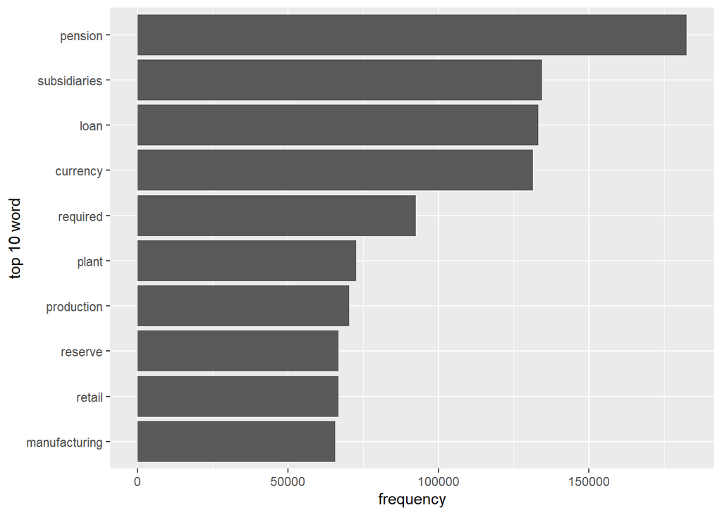

```r
# compnay level (entire corpus)
top_10_k <- tokens_tf_idf_k %>%
  group_by(word) %>%
  anti_join(stop_words) %>%
  summarise(n = sum(n)) %>%
  top_n(10, n) %>%
  arrange(desc(n)) %>%
  mutate(rank = row_number())

ggplot(top_10_k,
       aes(x = reorder(word, n),
           y = n)) +
  geom_bar(stat = "identity") +
  coord_flip() +
  ylab("frequency") +
  xlab("top 10 word")
```

```r
# tf-idf on industry level

l <- list()
for (i in 1:length(unique(K_token$GICS))) {

  this_industry <- unique(K_token$GICS)[i]
  print(this_industry)

  # corpus by each industry
  # and then calculate tf-idf
  tokens_tf_idf_k <- K_token %>%
    filter(GICS == this_industry) %>%
    bind_tf_idf(word,doc_id,n)

  l[[i]] <- tokens_tf_idf_k
}

tokens_tf_idf_k <- rbindlist(l)

hist(tokens_tf_idf_k$tf_idf,breaks = 200,main="TF-IDF plot")

## trimming
# remove too rare terms
tokens_tf_idf_k <- tokens_tf_idf_k %>%
  filter(tf_idf<0.002)

hist(tokens_tf_idf_k$tf_idf,breaks = 200,main="TF-IDF plot")

# remove too common terms across the documents
tokens_tf_idf_k <- tokens_tf_idf_k %>%
  filter(tf_idf>0.0003)

hist(tokens_tf_idf_k$tf_idf,breaks = 200,main="TF-IDF plot")
```

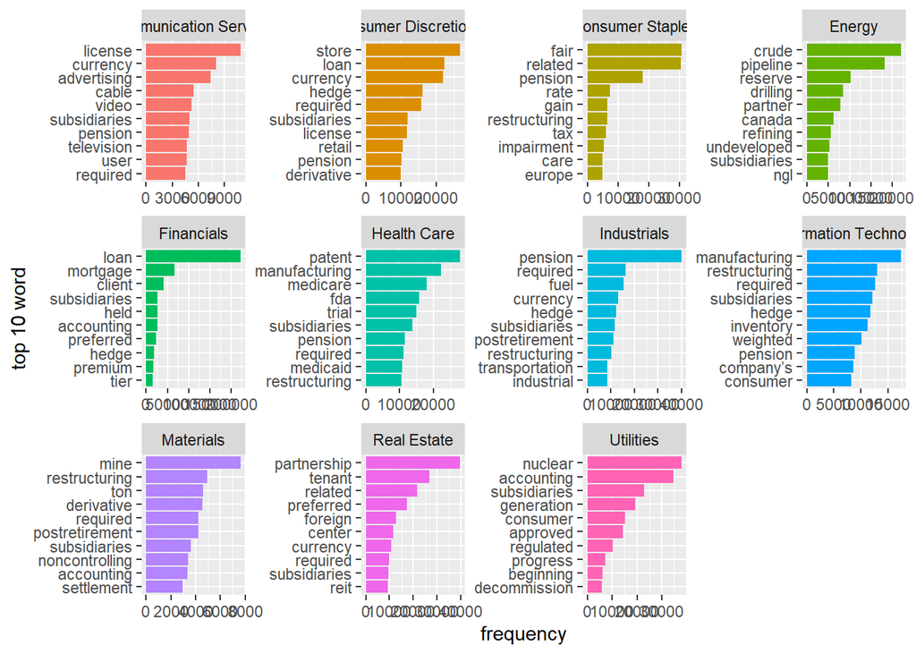

```r
# 11 GICS industries
top_10_k_industry <- tokens_tf_idf_k %>%
  group_by(word, factor(GICS)) %>%
  anti_join(stop_words) %>%
  summarise(n = sum(n)) %>%
  ungroup() %>%
  group_by(`factor(GICS)`) %>%
  top_n(10, n) %>%
  arrange(`factor(GICS)`, desc(n)) %>%
  mutate(rank = row_number()) %>%
  rename(GICS = `factor(GICS)`)

ggplot(top_10_k_industry,
       aes(x = reorder_within(word, n, GICS),
           y = n, group = factor(GICS),
           fill = factor(GICS))) +
  geom_bar(stat = "identity") +
  scale_x_reordered() +
  facet_wrap(~ GICS, scales = "free") +
  ylab("frequency") +
  xlab("top 10 word") +
  theme(legend.position = "none") +
  coord_flip()
```

```r
# tf-idf on market level

l <- list()
for (i in 1:length(unique(K_token$GICS_sub))) {
  this_market <- unique(K_token$GICS_sub)[i]
  print(this_market)

  # corpus by each industry
  # and then calculate tf-idf
  tokens_tf_idf_k <- K_token %>%
    filter(GICS_sub == this_market) %>%
    bind_tf_idf(word,doc_id,n)

  l[[i]] <- tokens_tf_idf_k
}

tokens_tf_idf_k <- rbindlist(l)

hist(tokens_tf_idf_k$tf_idf,breaks = 200,main="TF-IDF plot")

## trimming
# remove too rare terms
tokens_tf_idf_k <- tokens_tf_idf_k %>%
  filter(tf_idf<0.002)

hist(tokens_tf_idf_k$tf_idf,breaks = 200,main="TF-IDF plot")

# remove too common terms across the documents
tokens_tf_idf_k <- tokens_tf_idf_k %>%
  filter(tf_idf>0.0003)

hist(tokens_tf_idf_k$tf_idf,breaks = 200,main="TF-IDF plot")
```

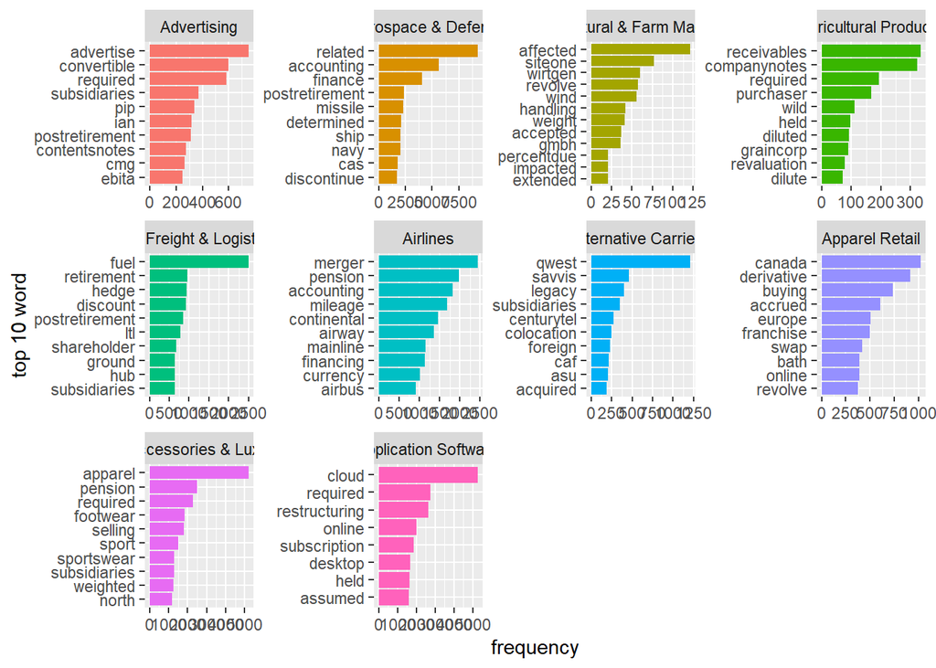

```r
# 128 markets (GICS sub)
top_10_k_market <- tokens_tf_idf_k %>%
  group_by(word, factor(GICS_sub)) %>%
  anti_join(stop_words) %>%
  summarise(n = sum(n)) %>%
  ungroup() %>%
  group_by(`factor(GICS_sub)`) %>%
  top_n(10, n) %>%
  arrange(`factor(GICS_sub)`, desc(n)) %>%
  mutate(rank = row_number()) %>%
  rename(GICS_sub = `factor(GICS_sub)`)

# there are total 128 markets
# which is too large number to display
# I will extract 10 markets to show as an example

top_10_k_market_sample <- top_10_k_market %>%
  head(., 100)

ggplot(top_10_k_market_sample,
       aes(x = reorder_within(word, n, GICS_sub),
           y = n, group = factor(GICS_sub),
           fill = factor(GICS_sub))) +
  geom_bar(stat = "identity") +
  scale_x_reordered() +
  facet_wrap(~ GICS_sub, scales = "free") +
  ylab("frequency") +
  xlab("top 10 word") +
  theme(legend.position = "none") +
  coord_flip()


# back up
save(top_10_k, top_10_k_industry, top_10_k_market, file = "top_10_k.rda")

rm(top_10_k, top_10_k_industry, top_10_k_market, tokens_tf_idf_k)
gc()
```

# PART B

## Single Company Sentiment Visualisation

I first introduce a simple sentiment visualisation using `edgar` package, in order to have a brief look at the sentiment changes of a company in interest over time period. I used `Nike` to explore the sentiments of its’ `10-Q` and `10-K` forms. This code can be useful to see sentiment details of edgar filings of a single company.

```r
# choose a target compnay
this_company <- "nike"
this_cik <- cik[which(grepl(this_company, companies$Security, ignore.case = TRUE))]
```

```r
cl <- makePSOCKcluster(detectCores()-2)
registerDoSNOW(cl)
clusterEvalQ(cl,
             library(edgar))

# set working directory as all the edgar filings are stored
setwd("D:/edgar")
# get sentiments from 10-Q filings of Nike
q <- foreach(i = 2009:2019, .options.snow = opts_year, .combine = rbind) %dopar% {
  setwd("D:/edgar")
  this_year <- edgar::getSentiment(this_cik,filing.year =i,form.type = "10-Q")
}

k <- foreach(i = 2009:2019, .options.snow = opts_year, .combine = rbind) %dopar% {
  setwd("D:/edgar")
  this_year <- getSentiment(this_cik,filing.year =i,form.type = "10-K")
}

# remove workers
doParallel::stopImplicitCluster()
stopCluster(cl)
rm(cl)
gc()
```

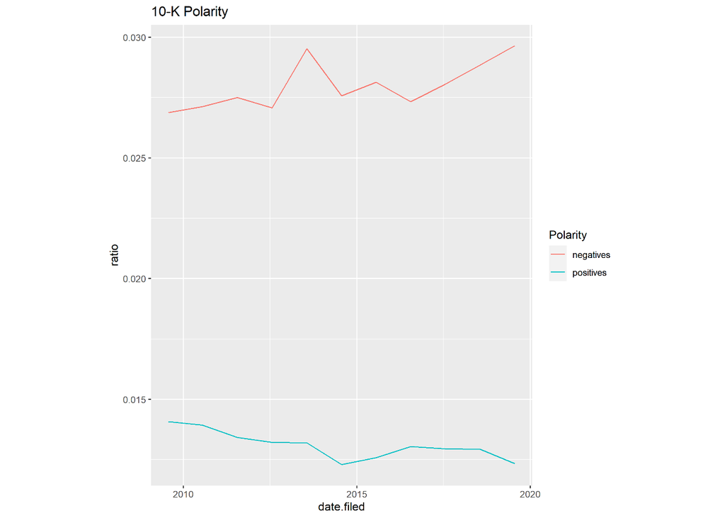

```r
nike_q <- q %>% select(date.filed,lm.dictionary.count,
                       lm.positive.count,lm.negative.count) %>%
  mutate(positives = lm.positive.count / lm.dictionary.count,
         negatives = lm.negative.count / lm.dictionary.count) %>%
  gather(key = "polarity", value = "ratio", positives, negatives) %>%
  ggplot(aes(x=date.filed,y=ratio, color = factor(polarity))) +
  geom_line() +
  ggtitle("10-Q Polarity") +
  labs(color = "Polarity")


nike_k <- k %>% select(date.filed,lm.dictionary.count,
                       lm.positive.count,lm.negative.count) %>%
  mutate(positives = lm.positive.count / lm.dictionary.count,
         negatives = lm.negative.count / lm.dictionary.count) %>%
  gather(key = "polarity", value = "ratio", positives, negatives) %>%
  ggplot(aes(x=date.filed,y=ratio, color = factor(polarity))) +
  geom_line() +
  ggtitle("10-K Polarity") +
  labs(color = "Polarity")

# ggsave("graph/nike_sentiment_q.png", plot = nike_q)
# ggsave("graph/nike_sentiment_k.png", plot = nike_k)
```

## Sentiment Association with Financial Indicators

In this section, I will figure out the relationship between `sentiment of edgar filings` and `stock price`. In common sense, I expect company stock price will decrease in the following day of filing date if the filing contains more negative sentiments and vice versa. In order to check whether changes in stock prices are significant or not, I tried regression models with `price change` and various `sentiment score` as variables. In addition, I used various sentiment dictionaries in order to put more variability and reliability on the regression results. Before sentiment analysis, price data should be downloaded from `Yahoo Finance` first using `tidyquant` package.

```r
# companies_q contains all available the companies
symbols <- companies_q %>% select(Symbol) %>% pull()

# some symbols need to changed
# according to Yahoo Finance format
# to obtain the prices
symbols <- str_replace_all(symbols, "\\.", "-")
symbols[str_detect(symbols, "\\.")]

con <- dbConnect(SQLite(), "edgar.sqlite")

for (i in 1:length(symbols)) {

  tryCatch(
    {
      message(paste0("Getting price information for ",i,"th symbol: ", symbols[i]))
      prices <- tq_get(symbols[i],
                       from = "2009-01-01",
                       to = "2020-01-01",
                       get = "stock.prices")
      # back up
      dbWriteTable(con, "prices", prices, append=TRUE)

      rm(prices)
      gc()
      message(paste0("Moved prices of ", symbols[i], " to database!"))
    },
    error=function(cond) {
      message(paste("unable to retrieve prices for this symbol:",
                    symbols[i]))
      message("This is the original error message:")
      message(cond)
      return(NA)
    }
  )
}

dbSendQuery(con, "CREATE INDEX symbol ON 'prices' (symbol)")

dbDisconnect(con)
```

**Dictionaries Used:**

- NRC (emotions)
- DictionaryHE (Henry’s finance-specific dictionary)
- DictionaryLM (LoughranMcDonald finance-specific dictionary)
- Afin

Using these four dictionaries, I will calculate the sentiment scores per dirctionary. Then, the scores can be used as independent variables to predict price movement of stocks. `10-Q` form and `10-K` form will be analysed *separately*, in order to see whethter there could be some difference in the regression results in the two formats.

### 10-Q sentiment analysis

```r
#### Data preparation (10-Q)

# this will be used to extract stock price
# per symbol one by one from database
symbols <- companies_q %>% select(Symbol) %>% pull()

# some symbols need to be changed
# according to Yahoo Finance format
symbols <- str_replace_all(symbols, "\\.", "-")
symbols[str_detect(symbols, "\\.")]

# to extract tokens by CIK one by one
# from database
# which has index on CIK
cik_list_q <- companies_q %>% select(CIK) %>% pull()

# this must be TRUE!
length(cik_list_q) == length(symbols)


opts <- optionSnow(length(cik_list_q))
# make clusters for parallel processing
cl <- makePSOCKcluster(detectCores()-1)
registerDoSNOW(cl)
clusterEvalQ(cl, {
  library(dplyr)
  library(RSQLite)
  library(zoo)
  library(tidyr)
  library(tidytext)
  library(data.table)
  library(SentimentAnalysis)
}
)

to_regress_q <- foreach(i = 1:length(cik_list_q),
                        .options.snow = opts,
                        .combine = rbind) %dopar% {

  con <- dbConnect(SQLite(), "edgar.sqlite")

  query_price <- paste0("SELECT symbol, date, volume, adjusted FROM prices WHERE symbol == '",
                        symbols[i], "'")
  query_token <- paste0("SELECT * FROM `tokens_tf_idf_Q` WHERE CIK == ",
                        cik_list_q[i])

  price <- dbGetQuery(con, query_price)
  all_data_token <- dbGetQuery(con, query_token)

  price$date <- zoo::as.Date(price$date)
  all_data_token$date.filed <- zoo::as.Date(all_data_token$date.filed)
  price <- as_tibble(price)
  all_data_token <- as_tibble(all_data_token)

  # extract filing date
  all_data_token %>%
    select(date.filed) %>%
    unique() %>%
    pull() -> date_filed

  # lapply will calculate
  # mean of adjusted prices
  # after 5 days the document filed
  # and adjust price before 1 day
  # to obtain the changes of the price
  # before and after the filings
  # i.e. average price after 5 days of filing date - price 1 day before filing date

  lapply(date_filed, function (x) {
    range_after <- seq(x, by = "day", length.out = 5)
    price_before <- price %>%
      filter(date == x-1) %>%
      select(adjusted) %>%
      pull()
    avg_price_after <- price %>%
      filter(date %in% range_after) %>%
      summarise(avg_price = mean(adjusted)) %>%
      pull()
    y <- tibble(
      date.filed = x,
      price_before = price_before,
      price_after = avg_price_after
    )
    return(y)
  }
  ) %>% rbindlist() -> price_before_after

  ## HE & LM
  # make document term matrix
  # to calculate sentiment scores using analyzeSentiment function
  dtm <- all_data_token %>%
    cast_dtm(doc_id, word, n)

  # get sentiment scores
  # extract only Henry's and LoughranMcDonalds sentiment scores
  sentiment_he_lm <- analyzeSentiment(dtm, stemming = F) %>%
    cbind(dtm$dimnames$Docs) %>%
    rename(doc_id = `dtm$dimnames$Docs`) %>%
    select(doc_id, SentimentHE, SentimentLM)

  sentiment_he_lm$doc_id <- as.character(sentiment_he_lm$doc_id)

  ## NRC

  all_data_token %>% inner_join(get_sentiments("nrc")) %>%
    group_by(doc_id, sentiment) %>%
    # not only the appearance of words
    # but also considered repitition of words in a document
    # i.e. sum of frequency value 'n'
    summarise(sentiment_level = sum(n)) %>%
    spread(sentiment,sentiment_level,fill = 0) -> emotions_nrc_10_Q

  # if there are missing sentiment columns
  # this code will adjust the number of columns
  # as a fixed format of 9 nrc emotions always

  if (length(colnames(emotions_nrc_10_K)) != 10) {
    colname <- c("anticipation", "fear", "anger", "joy",
                 "negative", "positive", "sadness", "surprise",
                 "trust")
    col_to_add <- colname[! colname %in% colnames(emotions_nrc_10_K)]
    suppressWarnings(emotions_nrc_10_K[, col_to_add] <- 0)

    rm(colname, col_to_add)
    gc()
  }

  # caculated scores depending on
  # the ratio of positive words / negative words
  # as word counts differ between the documents
  # simple subtraction scores (positive - negative)
  # can have distorted result
  sentiment_nrc <- emotions_nrc_10_Q %>%
    mutate(
      nrc_pos_neg = (positive + anticipation + joy + trust) /
        (anger + disgust + fear + negative + sadness)) %>%
    select(doc_id, nrc_pos_neg)

  ## AFIN

  all_data_token %>% inner_join(get_sentiments("afinn")) %>%
    group_by(doc_id) %>%
    summarise(sentiment_afinn = sum(value)) %>%
    select(doc_id ,sentiment_afinn) -> sentiment_afinn

  ## I have all sentiment scores now

  sentiment_he_lm %>%
    inner_join(sentiment_nrc) %>%
    inner_join(sentiment_afinn) %>%
    inner_join(distinct(all_data_token, doc_id, date.filed, GICS, GICS_sub)) %>%
    na.omit() -> sentiment_10_Q

  to_regress_sentiment_price <- sentiment_10_Q %>%
    inner_join(price_before_after) %>%
    mutate(price_diff = price_after - price_before) %>%
    na.omit()

  # select columns that we need
  # to optimise(minimise) the data size for regression
  to_regress_sentiment_price <- to_regress_sentiment_price %>%
    select(-c("price_before", "price_after"))

  to_regress_sentiment_price$direction <- sapply(to_regress_sentiment_price$price_diff,
                                                 function (x) ifelse(x > 0, 1,0))

  dbDisconnect(con)

  return(to_regress_sentiment_price)
}

doParallel::stopImplicitCluster()
stopCluster(cl)
rm(cl)
gc()

# backup
backup("edgar", "to_regress_Q", to_regress_q)
```

**Regression Analysis:**

- Linear Regression: Amount of price movement before and after the filing
- Logistic Regression: Direction of the price movement before and after the filing

```r
# brief data check before regression models

boxplot(to_regress_q$price_diff)
boxplot(to_regress_q$nrc_pos_neg)
boxplot(to_regress_q$SentimentHE)
boxplot(to_regress_q$SentimentLM)
boxplot(to_regress_q$sentiment_afinn)

rcompanion::plotNormalHistogram(to_regress_q$price_diff, breaks = 200)
rcompanion::plotNormalHistogram(to_regress_q$nrc_pos_neg, breaks = 200)
rcompanion::plotNormalHistogram(to_regress_q$SentimentHE, breaks = 200)
rcompanion::plotNormalHistogram(to_regress_q$SentimentLM, breaks = 200)
rcompanion::plotNormalHistogram(to_regress_q$sentiment_afinn, breaks = 200)

# there are some outliers and normality problems in variables
# which can affect the simpe linear regression result

q_price <- quantile(to_regress_q$price_diff, probs = seq(0,1,0.001))

# trimmed the price_diff data to remove some possible outliers (i.e. extreme values)
lower_q_price <- q_price[[11]]
upper_q_price <- q_price[[length(q_price)-11]]

to_regress_q_filtered <- to_regress_q %>%
  filter(price_diff >= lower_q_price,
         price_diff <= upper_q_price)

# Final check

# simple inverse hyperbolic sine transformation function
# to transform price_diff variable to fit normal distribution
ihs <- function(x) {
  y <- log(x + sqrt(x ^ 2 + 1))
  return(y)
}

rcompanion::plotNormalHistogram(to_regress_q$price_diff, breaks = 200)
rcompanion::plotNormalHistogram(to_regress_q_filtered$price_diff, breaks = 200)
rcompanion::plotNormalHistogram(ihs(to_regress_q_filtered$price_diff), breaks = 200)
# price_diff data looks more to follow normal distribution now
# tried inverse hyperbolic sine (ihs) transformation to make the data distributed more normal

rcompanion::plotNormalHistogram(to_regress_q_filtered$nrc_pos_neg, breaks = 200)
rcompanion::plotNormalHistogram(log(to_regress_q_filtered$nrc_pos_neg), breaks = 200)
# log transformation makes the sentiment value follow normal distribution more

rcompanion::plotNormalHistogram(to_regress_q_filtered$SentimentHE, breaks = 200)

rcompanion::plotNormalHistogram(to_regress_q_filtered$SentimentLM, breaks = 200)

rcompanion::plotNormalHistogram(to_regress_q_filtered$sentiment_afinn, breaks = 200)
```

```r
#### Company level (10-Q)

# it is expected that
# more positive sentiment
# -> price goes up more (i.e. higher value of price_diff)

# use simple linear regression
# to see the predictability of the sentiments
# on the price difference before and after the filing

model_sentiment_1 <- lm(ihs(price_diff) ~ log(nrc_pos_neg),
                        data = to_regress_q_filtered)
model_sentiment_2 <- lm(ihs(price_diff) ~ SentimentHE,
                        data = to_regress_q_filtered)
model_sentiment_3 <- lm(ihs(price_diff) ~ SentimentLM,
                        data = to_regress_q_filtered)
model_sentiment_4 <- lm(ihs(price_diff) ~ sentiment_afinn,
                        data = to_regress_q_filtered)

# use logistic regression
# to see the predictability of the sentiments
# on the direction of movement of price (up or down)
# after the filing

model_bin_sentiment_1 <- glm(direction ~ log(nrc_pos_neg),
                             family = binomial,
                             data = to_regress_q_filtered)
model_bin_sentiment_2 <- glm(direction ~ SentimentHE,
                             family = binomial,
                             data = to_regress_q_filtered)
model_bin_sentiment_3 <- glm(direction ~ SentimentLM,
                             family = binomial,
                             data = to_regress_q_filtered)
model_bin_sentiment_4 <- glm(direction ~ sentiment_afinn,
                             family = binomial,
                             data = to_regress_q_filtered)

stargazer::stargazer(model_sentiment_1,
                     model_sentiment_2,
                     model_sentiment_3,
                     model_sentiment_4,
                     model_bin_sentiment_1,
                     model_bin_sentiment_2,
                     model_bin_sentiment_3,
                     model_bin_sentiment_4,
                     type="text")
```

**Linear regression summary:**

None of the sentiments have significant predictability on price difference before and after the filing, as all p values are far larger than 0.05. In other words, *according to the linear regression result, 10-Q edgar filings’ sentiments and stock price seem to have no significant relationship*.

**Logistic regression summary:**

None of the sentiments have significant predictability on the direction of price change after the filing, as all p values are far larger than 0.05. In other words, *according to the logistic regression result, 10-Q edgar filings’ sentiments and stock price seem to have no significant relationship*.

```r
#### Industry level (10-Q)

# There are total 11 industries
# specify an target industry to investigate
# try regression by each industry
# to figure out in which industry
# sentiment can have predictive power on price movement
# try iteratively
# by changing the target number i in GICS[i]

GICS <- to_regress_q_filtered$GICS %>% unique()

target <- GICS[11]
to_regress_q_filtered_GICS <- to_regress_q_filtered %>%
  filter(GICS == target)

model_sentiment_1 <- lm(ihs(price_diff) ~ log(nrc_pos_neg),
                            data = to_regress_q_filtered_GICS)
model_sentiment_2 <- lm(ihs(price_diff) ~ SentimentHE,
                            data = to_regress_q_filtered_GICS)
model_sentiment_3 <- lm(ihs(price_diff) ~ SentimentLM,
                            data = to_regress_q_filtered_GICS)
model_sentiment_4 <- lm(ihs(price_diff) ~ sentiment_afinn,
                            data = to_regress_q_filtered_GICS)

model_bin_sentiment_1 <- glm(direction ~ log(nrc_pos_neg),
                             family = binomial,
                             data = to_regress_q_filtered_GICS)
model_bin_sentiment_2 <- glm(direction ~ SentimentHE,
                             family = binomial,
                             data = to_regress_q_filtered_GICS)
model_bin_sentiment_3 <- glm(direction ~ SentimentLM,
                             family = binomial,
                             data = to_regress_q_filtered_GICS)
model_bin_sentiment_4 <- glm(direction ~ sentiment_afinn,
                             family = binomial,
                             data = to_regress_q_filtered_GICS)

stargazer::stargazer(model_sentiment_1,
                     model_sentiment_2,
                     model_sentiment_3,
                     model_sentiment_4,
                     model_bin_sentiment_1,
                     model_bin_sentiment_2,
                     model_bin_sentiment_3,
                     model_bin_sentiment_4,
                     type="text")
```

**Linear regression summary:**

- Utilities - `sentiment_afinn` shows a possible predictive power on price change with p-value of 0.0128.
- Materials - `SentimentLM` shows a possible predictive power on price change with p-value of 0.02027.
- Real Estate - `SentimentLM` shows a possible predictive power on price change with p-value of 0.03576.

**Logistic regression summary:**

- Communication Services - `SentimentHE` shows a possible predictive power on price change with p-value of 0.0166.
- Consumer Discretionary - `SentimentLM` shows a possible predictive power on price change with p-value of 0.0378.

```r
#### Market level (10-Q)

# try iteratively
# by changing the target number i in GICS[i]

GICS_sub <- to_regress_q_filtered$GICS_sub %>% unique()

target <- GICS_sub[17]
to_regress_q_filtered_GICS_sub <- to_regress_q_filtered %>%
  filter(GICS_sub == target)

model_sentiment_1 <- lm(ihs(price_diff) ~ log(nrc_pos_neg),
                            data = to_regress_q_filtered_GICS_sub)
model_sentiment_2 <- lm(ihs(price_diff) ~ SentimentHE,
                            data = to_regress_q_filtered_GICS_sub)
model_sentiment_3 <- lm(ihs(price_diff) ~ SentimentLM,
                            data = to_regress_q_filtered_GICS_sub)
model_sentiment_4 <- lm(ihs(price_diff) ~ sentiment_afinn,
                            data = to_regress_q_filtered_GICS_sub)

model_bin_sentiment_1 <- glm(direction ~ log(nrc_pos_neg),
                             family = binomial,
                             data = to_regress_q_filtered_GICS_sub)
model_bin_sentiment_2 <- glm(direction ~ SentimentHE,
                             family = binomial,
                             data = to_regress_q_filtered_GICS_sub)
model_bin_sentiment_3 <- glm(direction ~ SentimentLM,
                             family = binomial,
                             data = to_regress_q_filtered_GICS_sub)
model_bin_sentiment_4 <- glm(direction ~ sentiment_afinn,
                             family = binomial,
                             data = to_regress_q_filtered_GICS_sub)

stargazer::stargazer(model_sentiment_1,
                     model_sentiment_2,
                     model_sentiment_3,
                     model_sentiment_4,
                     model_bin_sentiment_1,
                     model_bin_sentiment_2,
                     model_bin_sentiment_3,
                     model_bin_sentiment_4,
                     type="text")
```

**summary:**

There are only few markets in which sentiments seem to have significant relationships with stock price movement. For example, `Health Care Supplies` sentimentLM shows significant predictabilty on the direction of price change (p-value = 0.0382). However, in 10-Q forms, there is difficult to find stong relationship between sentiment scores and stock price movement in each market. There are 128 markets so I will not show the entire result here, but this approach can be applicable for further analysis.

### 10-K sentiment analysis

```r
#### Data preparation (10-K)

# entire process is same with the 10-Q form pre-processing above

symbols <- companies_k %>% select(Symbol) %>% pull()

# some symbols need to be changed
# according to Yahoo Finance format
symbols <- str_replace_all(symbols, "\\.", "-")
symbols[str_detect(symbols, "\\.")]

# to extract tokens
# which has index on CIK
cik_list_k <- companies_k %>% select(CIK) %>% pull()

# this must be true
length(cik_list_k) == length(symbols)

opts <- optionSnow(length(cik_list_k))

# make clusters for parallel processing
cl <- makePSOCKcluster(detectCores()-1)
registerDoSNOW(cl)
clusterEvalQ(cl, {
  library(dplyr)
  library(RSQLite)
  library(zoo)
  library(tidyr)
  library(tidytext)
  library(data.table)
  library(SentimentAnalysis)
}
)

to_regress_k <- foreach(i = 1:length(cik_list_k),
                        .options.snow = opts,
                        .combine = rbind) %dopar% {

  con <- dbConnect(SQLite(), "edgar.sqlite")

  query_price <- paste0("SELECT symbol, date, volume, adjusted FROM prices WHERE symbol == '",
                        symbols[i], "'")
  query_token <- paste0("SELECT * FROM `tokens_tf_idf_K` WHERE CIK == ",
                        cik_list_k[i])

  price <- dbGetQuery(con, query_price)
  all_data_token <- dbGetQuery(con, query_token)

  price$date <- zoo::as.Date(price$date)
  all_data_token$date.filed <- zoo::as.Date(all_data_token$date.filed)
  price <- as_tibble(price)
  all_data_token <- as_tibble(all_data_token)

  all_data_token %>%
    select(date.filed) %>%
    unique() %>%
    pull() -> date_filed

  # lapply calculates mean of adjusted prices
  # after 5 days the document filed
  # and adjust price before 1 day
  # to obtain the changes of the price
  # before and after the filings

  lapply(date_filed, function (x) {
    range_after <- seq(x, by = "day", length.out = 5)
    price_before <- price %>%
      filter(date == x-1) %>%
      select(adjusted) %>%
      pull()
    avg_price_after <- price %>%
      filter(date %in% range_after) %>%
      summarise(avg_price = mean(adjusted)) %>%
      pull()
    y <- tibble(
      date.filed = x,
      price_before = price_before,
      price_after = avg_price_after
    )
    return(y)
  }
  ) %>% rbindlist() -> price_before_after

  ## HE & LM
  dtm <- all_data_token %>%
    cast_dtm(doc_id, word, n)

  sentiment_he_lm <- analyzeSentiment(dtm, stemming = F) %>%
    cbind(dtm$dimnames$Docs) %>%
    rename(doc_id = `dtm$dimnames$Docs`) %>%
    select(doc_id, SentimentHE, SentimentLM)

  sentiment_he_lm$doc_id <- as.character(sentiment_he_lm$doc_id)

  ## NRC

  all_data_token %>% inner_join(get_sentiments("nrc")) %>%
    group_by(doc_id, sentiment) %>%
    # also considered repitition of words in a document
    # i.e. sum of frequency value 'n'
    summarise(sentiment_level = sum(n)) %>%
    spread(sentiment,sentiment_level,fill = 0) -> emotions_nrc_10_K

  # if there are missing sentiment columns
  # this code will adjust the number of columns
  # as a fixed format of 9 nrc emtions always

  if (length(colnames(emotions_nrc_10_K)) != 11) {
    colname <- c("anticipation", "fear", "anger", "joy", "disgust",
                 "negative", "positive", "sadness", "surprise",
                 "trust")
    col_to_add <- colname[! colname %in% colnames(emotions_nrc_10_K)]
    suppressWarnings(emotions_nrc_10_K[, col_to_add] <- 0)

    rm(colname, col_to_add)
    gc()
  }

  # word counts can vary between the documents
  # so I used ratio for nrc sentiment score

  sentiment_nrc <- emotions_nrc_10_K %>%
    mutate(
      nrc_pos_neg = (positive + anticipation + joy + trust) /
        (anger + disgust + fear + negative + sadness)) %>%
    select(doc_id, nrc_pos_neg)

  ## AFIN

  all_data_token %>% inner_join(get_sentiments("afinn")) %>%
    group_by(doc_id) %>%
    # also consider repitition of words in a document
    summarise(sentiment_afinn = sum(value)) %>%
    select(doc_id ,sentiment_afinn) -> sentiment_afinn

  ## I have all_sentiments now

  sentiment_he_lm %>%
    inner_join(sentiment_nrc) %>%
    inner_join(sentiment_afinn) %>%
    inner_join(distinct(all_data_token, doc_id, date.filed, GICS, GICS_sub)) %>%
    na.omit() -> sentiment_10_Q

  to_regress_sentiment_price <- sentiment_10_Q %>%
    inner_join(price_before_after) %>%
    mutate(price_diff = price_after - price_before) %>%
    na.omit()

  # select columns that we need
  # to optimise(minimise) the data size for regression
  to_regress_sentiment_price <- to_regress_sentiment_price %>%
    select(-c("price_before", "price_after"))

  to_regress_sentiment_price$direction <- sapply(to_regress_sentiment_price$price_diff,
                                                 function (x) ifelse(x > 0, 1,0))

  dbDisconnect(con)

  return(to_regress_sentiment_price)
}

doParallel::stopImplicitCluster()
stopCluster(cl)
rm(cl)
gc()

# backup
backup("edgar", "to_regress_K", to_regress_k)
```

**Regression Analysis:**

- Linear Regression: Amount of price movement before and after the filing
- Logistic Regression: Direction of the price movement before and after the filing

```r
# brief data check before regression models

boxplot(to_regress_k$price_diff)
boxplot(to_regress_k$nrc_pos_neg)
boxplot(to_regress_k$SentimentHE)
boxplot(to_regress_k$SentimentLM)
boxplot(to_regress_k$sentiment_afinn)

rcompanion::plotNormalHistogram(to_regress_k$price_diff, breaks = 200)
rcompanion::plotNormalHistogram(to_regress_k$nrc_pos_neg, breaks = 200)
rcompanion::plotNormalHistogram(to_regress_k$SentimentHE, breaks = 200)
rcompanion::plotNormalHistogram(to_regress_k$SentimentLM, breaks = 200)
rcompanion::plotNormalHistogram(to_regress_k$sentiment_afinn, breaks = 200)

# there are some outliers and normality problems in variables
# which can affect the simpe linear regression result

q_price <- quantile(to_regress_k$price_diff, probs = seq(0,1,0.001))
q_lm <- quantile(to_regress_k$SentimentLM, probs = seq(0,1,0.001))
q_afinn <- quantile(to_regress_k$sentiment_afinn, probs = seq(0,1,0.001))

# trimmed the price_diff data to remove some possible outliers (i.e. extreme values)

lower_q_price <- q_price[[11]]
upper_q_price <- q_price[[length(q_price)-11]]
lower_q_lm <- q_lm[[5]]
upper_q_afinn <- q_afinn[[length(q_afinn)-5]]

to_regress_k_filtered <- to_regress_k %>%
  filter(price_diff >= lower_q_price,
         price_diff <= upper_q_price,
         SentimentLM >= lower_q_lm,
         sentiment_afinn <= upper_q_afinn
         )

# Final check

rcompanion::plotNormalHistogram(to_regress_k$price_diff, breaks = 200)
rcompanion::plotNormalHistogram(to_regress_k_filtered$price_diff, breaks = 200)
rcompanion::plotNormalHistogram(ihs(to_regress_k_filtered$price_diff), breaks = 200)
# price_diff data looks more to follow normal distribution now
# tried inverse hyperbolic sine (ihs) transformation to make the data distributed more normal

rcompanion::plotNormalHistogram(to_regress_k_filtered$nrc_pos_neg, breaks = 200)
rcompanion::plotNormalHistogram(log(to_regress_k_filtered$nrc_pos_neg), breaks = 200)
# log transformation makes the sentiment value follow normal distribution more

rcompanion::plotNormalHistogram(to_regress_k_filtered$SentimentHE, breaks = 200)

rcompanion::plotNormalHistogram(to_regress_k_filtered$SentimentLM, breaks = 200)

rcompanion::plotNormalHistogram(to_regress_k_filtered$sentiment_afinn, breaks = 200)
```

```r
#### Company level (10-K)

# it is expected that
# more positive sentiment
# -> price goes up more (i.e. higher value of price_diff)

# use simple linear regression
# to see the predictability of the sentiments
# on the price difference before and after the filing

model_sentiment_1 <- lm(ihs(price_diff) ~ log(nrc_pos_neg),
                        data = to_regress_k_filtered)
model_sentiment_2 <- lm(ihs(price_diff) ~ SentimentHE,
                        data = to_regress_k_filtered)
model_sentiment_3 <- lm(ihs(price_diff) ~ SentimentLM,
                        data = to_regress_k_filtered)
model_sentiment_4 <- lm(ihs(price_diff) ~ sentiment_afinn,
                        data = to_regress_k_filtered)

# use logistic regression
# to see the predictability of the sentiments
# on the direction of movement of price (up or down)
# after the filing

model_bin_sentiment_1 <- glm(direction ~ log(nrc_pos_neg),
                             family = binomial,
                             data = to_regress_k_filtered)
model_bin_sentiment_2 <- glm(direction ~ SentimentHE,
                             family = binomial,
                             data = to_regress_k_filtered)
model_bin_sentiment_3 <- glm(direction ~ SentimentLM,
                             family = binomial,
                             data = to_regress_k_filtered)
model_bin_sentiment_4 <- glm(direction ~ sentiment_afinn,
                             family = binomial,
                             data = to_regress_k_filtered)

stargazer::stargazer(model_sentiment_1,
                     model_sentiment_2,
                     model_sentiment_3,
                     model_sentiment_4,
                     model_bin_sentiment_1,
                     model_bin_sentiment_2,
                     model_bin_sentiment_3,
                     model_bin_sentiment_4,
                     type="text")
```

**Linear regression summary:**

- `SentimentLM` shows a possible predictive power on price change with p-value of 0.00748.
- `nrc_pos_neg` shows a possible predictive power on price change with p-value of 0.0192.

**Logistic regression summary:**

None of the sentiments have significant predictability on the direction of price change after the filing, as all p values are far larger than 0.05. In other words, *according to the logistic regression result, 10-K edgar filings’ sentiments and stock price seem to have no significant relationship*.

```r
#### Industry level (10-K)

# There are total 11 industries
# specify an target industry to investigate
# try regression by each industry
# to figure out in which industry
# sentiment can have predictive power on price movement
# try iteratively
# by changing the target number i in GICS[i]

GICS <- to_regress_k_filtered$GICS %>% unique()

target <- GICS[11]
to_regress_k_filtered_GICS <- to_regress_k_filtered %>%
  filter(GICS == target)

model_sentiment_1 <- lm(ihs(price_diff) ~ log(nrc_pos_neg),
                            data = to_regress_k_filtered_GICS)
model_sentiment_2 <- lm(ihs(price_diff) ~ SentimentHE,
                            data = to_regress_k_filtered_GICS)
model_sentiment_3 <- lm(ihs(price_diff) ~ SentimentLM,
                            data = to_regress_k_filtered_GICS)
model_sentiment_4 <- lm(ihs(price_diff) ~ sentiment_afinn,
                            data = to_regress_k_filtered_GICS)

model_bin_sentiment_1 <- glm(direction ~ log(nrc_pos_neg),
                             family = binomial,
                             data = to_regress_k_filtered_GICS)
model_bin_sentiment_2 <- glm(direction ~ SentimentHE,
                             family = binomial,
                             data = to_regress_k_filtered_GICS)
model_bin_sentiment_3 <- glm(direction ~ SentimentLM,
                             family = binomial,
                             data = to_regress_k_filtered_GICS)
model_bin_sentiment_4 <- glm(direction ~ sentiment_afinn,
                             family = binomial,
                             data = to_regress_k_filtered_GICS)

stargazer::stargazer(model_sentiment_1,
                     model_sentiment_2,
                     model_sentiment_3,
                     model_sentiment_4,
                     model_bin_sentiment_1,
                     model_bin_sentiment_2,
                     model_bin_sentiment_3,
                     model_bin_sentiment_4,
                     type="text")
```

**linear regression summary:**

- Information Technology - `SentimentLM` shows a possible predictive power on price change with p-value of 0.0182.
- Utility - `nrc_pos_neg` shows a possible predictive power on price change with p-value of 0.0207.
- Financials - `nrc_pos_neg` shows a possible predictive power on price change with p-value of 0.0151.
- Materials - `SentimentHE` shows a possible predictive power on price change with p-value of 0.03785.
- Real Estate - `SentimentHE` and `sentiment_afinn` shows a possible predictive power on price change with p-value of 0.01774 and 0.0426.

**logistic regression summary:**

- Health care - `sentiment_afinn` shows a possible predictive power on price change with p-value of 0.0192.
- Information Technology - `SentimentLM` shows a possible predictive power on price change with p-value of 0.038048.
- Utility - `nrc_pos_neg` shows a possible predictive power on price change with p-value of 0.0488.
- Energy - `sentiment_afinn` shows a possible predictive power on price change with p-value of 0.021.

```r
#### Market level (10-K)

# try iteratively
# by changing the target number i in GICS[i]

GICS_sub <- to_regress_k_filtered$GICS_sub %>% unique()

target <- GICS_sub[6]
to_regress_k_filtered_GICS_sub <- to_regress_k_filtered %>%
  filter(GICS_sub == target)

model_sentiment_1 <- lm(ihs(price_diff) ~ log(nrc_pos_neg),
                            data = to_regress_k_filtered_GICS_sub)
model_sentiment_2 <- lm(ihs(price_diff) ~ SentimentHE,
                            data = to_regress_k_filtered_GICS_sub)
model_sentiment_3 <- lm(ihs(price_diff) ~ SentimentLM,
                            data = to_regress_k_filtered_GICS_sub)
model_sentiment_4 <- lm(ihs(price_diff) ~ sentiment_afinn,
                            data = to_regress_k_filtered_GICS_sub)

model_bin_sentiment_1 <- glm(direction ~ log(nrc_pos_neg),
                             family = binomial,
                             data = to_regress_k_filtered_GICS_sub)
model_bin_sentiment_2 <- glm(direction ~ SentimentHE,
                             family = binomial,
                             data = to_regress_k_filtered_GICS_sub)
model_bin_sentiment_3 <- glm(direction ~ SentimentLM,
                             family = binomial,
                             data = to_regress_k_filtered_GICS_sub)
model_bin_sentiment_4 <- glm(direction ~ sentiment_afinn,
                             family = binomial,
                             data = to_regress_k_filtered_GICS_sub)

stargazer::stargazer(model_sentiment_1,
                     model_sentiment_2,
                     model_sentiment_3,
                     model_sentiment_4,
                     model_bin_sentiment_1,
                     model_bin_sentiment_2,
                     model_bin_sentiment_3,
                     model_bin_sentiment_4,
                     type="text")
```

**summary:**

There are some markets in which sentiments seem to have significant relationships with stock price movement. For example, in `Application Software`, sentiment_afinn shows significant predictabilty on the price change (linear: p-value = 0.02139, logistic: p-value = 0.0242). There are 128 markets so I will not show the entire result here, but this approach can be applicable for further analysis.

### Overall summary on the result

In summary, *sentiment scores of 10-K forms have better performance than those of 10-Q forms on predicting the stock price movement*. Even though 10-Q form sentiment scores have shown good predictions on stock price movement in some industries or markets, the overall predict power is weaker than 10-K forms. Various sentiment scores of 10-K form have shown some significant prediction power on stock price change in all levels (company, industry and market level) of analysis. Particularly, *Loughran and McDonald sentiment score shows the best performance in predicting the stock price in general*. However, other sentiment scores also show some predictability in a particular industry or market. Most of the relationships between sentiment score and price movement (i.e. price after the filing - price before the filing) have *positive correlation*. That is, *more positive sentiments in filings can lead to more increase in stock price after the filing* as I expected before the anlaysis. However, some sentiments sometimes show negative correlation with price movement in particular industries or markets, which may require further analysis to figure out the reason. All results are based on naive approach with simple linear regression and logistic regression. Furthermore, data used in the anlaysis may not be adequate or fully engineered for the statistical anlaysis. Therefore, different approach, like using closing price to calculate price movement or proper data transformation, can result in more robust and meaningful outcome.